# Lab 2

Will Lowe

11 January 2015

## Text Classification: What’s in the New York Times?

In this demonstration we will be using a corpus of article titles and description from the New York Times. The classification task is to determine which of 27 subject categories a story is from. You can find a list of these categories in the accompanying document.

We begin by loading the library we will be using for classification

```r
library(RTextTools) ## may need to install.packages('RTextTools') first
```

The documents we will be using are in the file on the course pages

```r
load("nytimes-sample.RData") ## object is called nytimes.sample
```

This is a *data.matrix*, so we first see what sorts of variables we have available to us

```r
colnames(nytimes.sample)
```

```
## [1] "X"          "Date"       "Article_ID" "Title"      "Subject"
## [6] "Topic.Code" "Topic"
```

We will be most interested in the text fields `Subject` and `Title` and the numerical subject category label `Topic.Code`, which is conveniently translated as `Topic`. For convenience the code to topic mapping is shown in the table.

```r
codes <- read.csv('topics-nyt.csv', row.names=1)
```

New York Times Index topic codes and their descriptive names

|  | Topic |
| --- | --- |
| 1 | Macroeconomics |
| 2 | Civil Rights |
| 3 | Health |
| 4 | Agriculture |
| 5 | Labor, Immigration, and Employment |
| 6 | Education |
| 7 | Environment |
| 8 | Energy |
| 10 | Transportation |
| 12 | Law, Crime, and Family Issues |
| 13 | Social welfare |
| 14 | Community Development and Housing |
| 15 | Banking, Finance and Domestic Commerce |
| 16 | Defense |
| 17 | Space, Science, Technology, and Communications |
| 18 | Foreign Trade |
| 19 | International Affairs |
| 20 | Federal Government Operations |
| 21 | Public Lands and Water Management |
| 24 | State and Local Government Administration |
| 26 | Weather and Natural Disasters |
| 27 | Fires |
| 28 | Arts and Entertainment |
| 29 | Sports and Recreation |
| 30 | Death Notices |
| 31 | Churches and Religion |
| 99 | Other, Miscellaneous, and Human Interest |

```r
head(nytimes.sample[,c('Title', 'Subject')])
```

```
##                                                                                     Title
## 1                           Nation's Smaller Jails Struggle To Cope With Surge in Inmates
## 2                                         FEDERAL IMPASSE SADDLING STATES WITH INDECISION
## 3                     Long, Costly Prelude Does Little To Alter Plot of Presidential Race
## 4                            Top Leader of the Bosnian Serbs Now Under Attack From Within
## 5 BATTLE OVER THE BUDGET: THE OVERVIEW; LEADERS IN HOUSE DROP G.O.P. PLAN ON U.S. WORKERS
## 6                                         South African Democracy Stumbles on Old Rivalry
##                                                                                      Subject
## 1                                                  Jails overwhelmed with hardened criminals
## 2                                                    Federal budget impasse affect on states
## 3                                                 Contenders for 1996 Presedential elections
## 4                                                 Bosnian Serb leader criticized from within
## 5 Battle over budget: Republican leaders abandon strategy of using closed Government offices
## 6                                                         political violence in south africa
```

You can see whether your coding corresponds to the actual labels human coders assigned them

```r
head(nytimes.sample[,c('Topic','Topic.Code')])
```

```
##                           Topic Topic.Code
## 1 Law, Crime, and Family Issues         12
## 2 Federal Government Operations         20
## 3 Federal Government Operations         20
## 4         International Affairs         19
## 5                Macroeconomics          1
## 6         International Affairs         19
```

In order to build a document classifier we first transform this nice readable dataset into a sparse matrix of word counts.

As part of the process of doing that we’ll take the opportunity to throw out number words, reduce to word stems, and weight the resulting word counts using a standard term frequency-inverse document frequency (tfidf) transformation.

```r
matrix <- create_matrix(cbind(nytimes.sample$Title,nytimes.sample$Subject),
                        language="english",
                        removeNumbers=TRUE,
                        stemWords=TRUE,
                        weighting=tm::weightTfIdf)
```

where the `cbind` function ties together two columns from `nytimes.sample`. We handed in the `Title` and `Subject` fields together because we expect that they both provide information about the topic code. We could have done more (or less) pre-processing as we counted and transformed the words. See the help for `create_matrix` for details.

Now that we have a suitable representation for our documents we create a container object to hold both them and their category labels. We’ll use the container to train and also to test fitted classifiers

```r
set.seed(1234) ## so your cases will be mine
training.cases <- 1:2000
test.cases <- 2001:3104
corpus <- create_container(matrix, nytimes.sample$Topic.Code,
                           trainSize=training.cases,
                           testSize=test.cases,
                           virgin=FALSE)
```

```r
 models <- train_models(corpus, algorithms=c("SVM"))
```

Normally in R we would want to summarise a fitted model. In this case however, the parameters are unlikely to be particularly illuminating (and there are several hundred of them), so no such methods are provided.

If we had wanted to train more or different models, we would have had to put their names in the `algorithms` parameter. The options are

```r
print_algorithms()
```

```
## [1] "BAGGING"  "BOOSTING" "GLMNET"   "MAXENT"   "NNET"     "RF"
## [7] "SLDA"     "SVM"      "TREE"
```

and you can spend a happy afternoon reading about them on the internet. (Mac users might want to avoid ‘maxent’ in this version)

Now that our single classifier is trained we would like to see how well it works

```r
results <- classify_models(corpus, models)
```

This particular function hides a fair amount of detail about the model, which is usually what we want. Looking at the first few results

```r
head(results)
```

```
##   SVM_LABEL  SVM_PROB
## 1        12 0.2851366
## 2         3 0.5829630
## 3        12 0.8407219
## 4        19 0.2926087
## 5        16 0.6889887
## 6        16 0.4788193
```

we see the topic in the first column and the probability that the classifier assigned this topic in the second column. Despite more than 20 possible categories this model seems rather confident. This is not necessarily a good thing.

As a first look at the performance of the model, let us see what how likely it is to put a document in the right category, and then examine what sorts of errors are made.

The library comes with various forms of ‘analytics’, that is: performance summaries. Let’s compute all of them for the corpus we trained with and the results we got

```r
analytics <- create_analytics(corpus, results)
```

The analytics object is a vast sprawling thing that you can read about on its help page.

One summary we can make from it is the probability that the classifier puts a document in the right category (recall), which we might want to break down by category. Another is the probability that a document is in a category when the model says it is (precision). Actually we want these things often enough that they get their own function, the idiosyncratically punctuated

```r
 pr <- create_precisionRecallSummary(corpus, results)
```

which we show in the Table, including the F-measure which combines precision and recall. The is useful if you like reducing vast amounts of disparate information to single number summaries. We don’t, so we’ll ignore it. %

Precision, recall and the F measure for classifier performance

|  | precision | recall | F |
| --- | --- | --- | --- |
| 1 | 0.76 | 0.72 | 0.74 |
| 2 | 0.52 | 0.47 | 0.49 |
| 3 | 0.63 | 0.64 | 0.63 |
| 4 |  | 0.00 |  |
| 5 | 0.74 | 0.53 | 0.62 |
| 6 | 0.74 | 0.72 | 0.73 |
| 7 | 0.33 | 0.30 | 0.31 |
| 8 | 0.40 | 0.13 | 0.20 |
| 10 | 0.25 | 0.15 | 0.19 |
| 12 | 0.42 | 0.67 | 0.52 |
| 13 |  | 0.00 |  |
| 14 | 1.00 | 0.21 | 0.35 |
| 15 | 0.46 | 0.46 | 0.46 |
| 16 | 0.80 | 0.59 | 0.68 |
| 17 | 0.57 | 0.43 | 0.49 |
| 18 | 0.00 | 0.00 |  |
| 19 | 0.42 | 0.73 | 0.53 |
| 20 | 0.66 | 0.60 | 0.63 |
| 21 |  | 0.00 |  |
| 24 | 0.56 | 0.47 | 0.51 |
| 26 | 0.61 | 0.61 | 0.61 |
| 27 | 0.67 | 0.40 | 0.50 |
| 28 | 0.30 | 0.33 | 0.31 |
| 29 | 0.84 | 0.49 | 0.62 |
| 30 | 0.33 | 0.20 | 0.25 |
| 31 | 0.80 | 0.24 | 0.37 |
| 99 | 0.40 | 0.29 | 0.34 |

What difference do these errors make? One way to check this we can make a time series of Defense/International Affairs stories as a proportion of all New York Times stories and compare it to the time series we would have gotten if we had used our classifier’s decisions instead.

First, let’s pull out the rows corresponding to test documents from the original data set

```r
testdata <- nytimes.sample[test.cases,]
```

and add the model’s predictions about their topic as a new column

```r
testdata$Model.Topic.Code <- results[,1] ## just the topic code
```

To make our time series we have to aggregate a bit, so let’s add a monthly indicator variable.

```r
testdata$month <- cut(testdata$Date, 'month')
```

This will allow us to aggregate documents that appear within the same month. This smooths the data a bit.

```r
bigt <- with(testdata, table(Topic.Code, month))
```

This big cross tabulation has months as columns and aggregated topic code counts as rows. It’s a bit unwieldy to look at, so let us summarise the amount of attention given to ‘International Affairs’ and `Defense’ (codes 19 and 16) as a proportion of all the different sorts of news.

```r
all.news <- colSums(bigt)
foreigners <- colSums(bigt[c('19','16'),])  ## careful with the quotes
time <- as.Date(colnames(bigt)) ## turn our indicator back into date
```

with these three quantities in hand, we get a Figure.

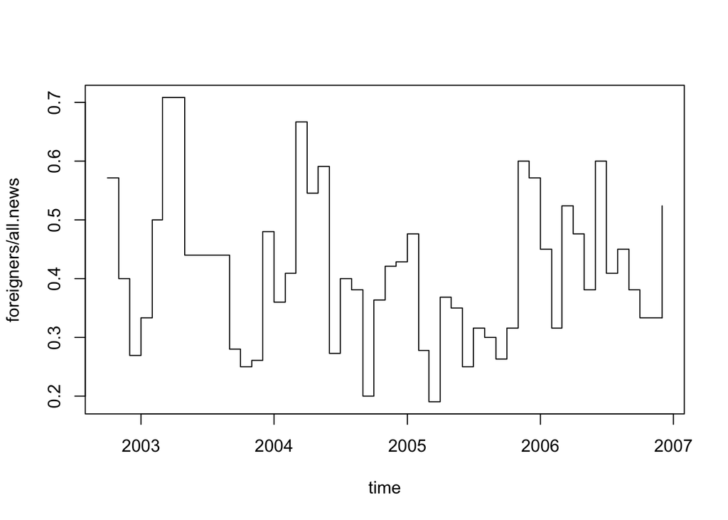

```r
plot(time, foreigners/all.news, type='s')
```

Let’s see how that *would have* gone if we did not know the topic codes and had to use the classifier outputs.

We recompute with the model’s topic codes

```r
bigt.model <- with(testdata, table(Model.Topic.Code, month))
foreigners.model <- colSums(bigt.model[c('19','16'),])
```

and replot.

Finally we can plot the differences.

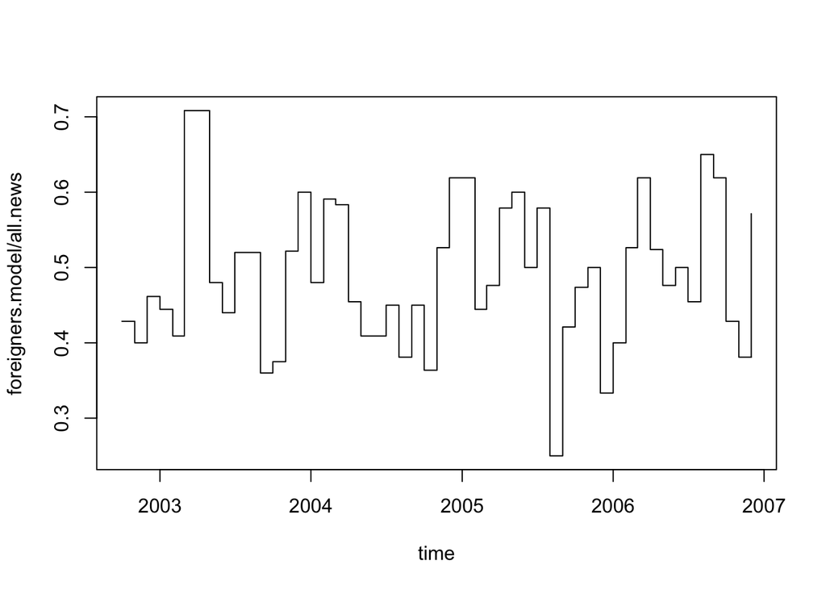

```r
plot(time,  foreigners.model/all.news, type='s')
```

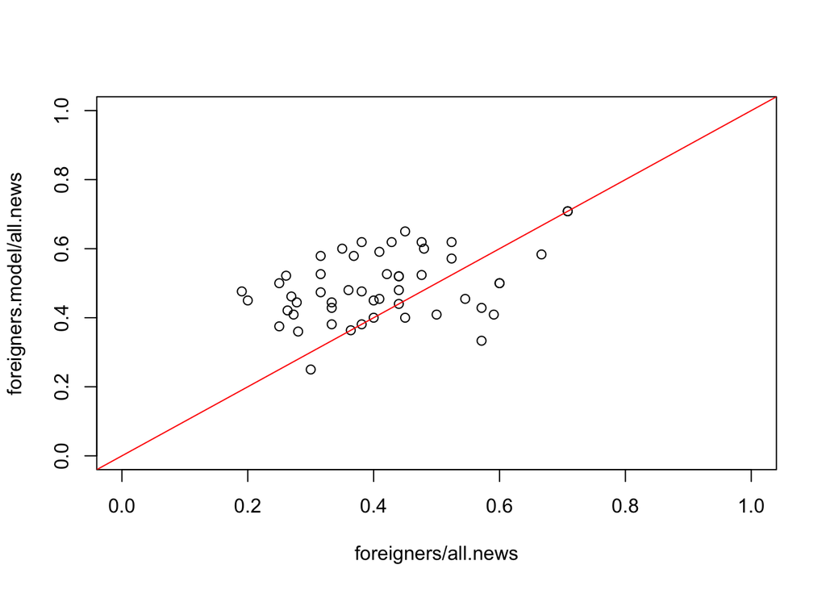

```r
plot(foreigners/all.news, foreigners.model/all.news, xlim=c(0,1), ylim=c(0,1))
abline(a=0,b=1,col='red')
```